# Data_desc

##Lectura base de datos:

```r
library(ggplot2)
library(dplyr)
library(tidyr)
```

Modificacion de caracteres especiales:

```r
#Modificaciones con tildes, enes y otros caracteres raros
if(TRUE){ #TUrn false if causes problems #Ineficiencia
  df <- data.frame(apply(df,2,function(x) gsub("Ã‰",'E',x)))#e tilde mayus
  df <- data.frame(apply(df,2,function(x) gsub("Ã",'A',x))) #tilde a mayus

  df <- data.frame(apply(df,2,function(x) gsub("Ã",'i',x))) #tilde i
  df <- data.frame(apply(df,2,function(x) gsub("i³",'o',x)))#tilde o
  df <- data.frame(apply(df,2,function(x) gsub("i±",'n',x)))# eñe
  df <- data.frame(apply(df,2,function(x) gsub("i©",'e',x)))# tilde e
  df <- data.frame(apply(df,2,function(x) gsub("iº",'u',x)))#tilde u
  df <- data.frame(apply(df,2,function(x) gsub("i‘",'N',x)))#Ñ mayuscula
}
```

Los elementos en zona rural carecen de barrios o comunas. Al solo sumar 258, se decide eliminarlos del analisis.

```r
df2 <- df[df$TIPO_GEOCOD!="ZONA RURAL",]
```

Se considera que “CON MUERTO” es equivalente a “MUERTO” para la columna “GRAVEDAD”: Se considera que “Caida Ocupante” es equivalente a “Caida de Ocupante” en la columna “CLASE”

```r
df2[df2$GRAVEDAD == "CON MUERTO",]$GRAVEDAD <- "MUERTO"

df2[df2$CLASE == levels(df2$CLASE)[5] | df2$CLASE == levels(df2$CLASE)[3] ,]$CLASE <- "Caida Ocupante"
```

```r
clase_c<-count(df2, CLASE)
clase_c[order(-clase_c$n),]
```

```
## # A tibble: 9 x 2
##   CLASE                   n
##   <fct>               <int>
## 1 Choque             141305
## 2 Otro                22017
## 3 Atropello           20667
## 4 Caida Ocupante      18532
## 5 Volcamiento          6613
## 6 Incendio               24
## 7 ""                      6
## 8 "Choque "               3
## 9 Choque y Atropello      1
```

```r
count(df2, GRAVEDAD)
```

```
## # A tibble: 3 x 2
##   GRAVEDAD        n
##   <fct>       <int>
## 1 HERIDO     114022
## 2 MUERTO       1239
## 3 SOLO DANOS  93907
```

Hay 5 radicados repetidos para 27 filas repetidas entre si (una fila tiene almenos otra repetida), discusión de si remover.

```r
#Repetidos por radicado, POR id son unicos
library(tidyverse)
aggregate(RADICADO ~ GRAVEDAD, data = df, FUN = length)
```

```
##     GRAVEDAD RADICADO
## 1 CON MUERTO       73
## 2     HERIDO   114200
## 3     MUERTO     1175
## 4 SOLO DANOS    93973
```

```r
aggregate(CBML ~ GRAVEDAD, data = df, FUN = length)
```

```
##     GRAVEDAD   CBML
## 1 CON MUERTO     73
## 2     HERIDO 114200
## 3     MUERTO   1180
## 4 SOLO DANOS  93973
```

```r
#df[duplicated(df$RADICADO), ] estos son los radicados repetidos
```

## Graficas y relación de variables:

Inicialente se consideran las posibles relaciones entre ciertas Comunas y la frecuencia, gravedad y tipo de accidentes.

###Gravedad y comunas

```r
comunas <- count(df2, COMUNA) #EN su mayoria las comunas con menos de 4 accidentes son tabulaciones erroneas d eun barrio
head(comunas[order(-comunas$n),],25)
```

```
## # A tibble: 25 x 2
##    COMUNA               n
##    <fct>            <int>
##  1 La Candelaria    43715
##  2 Laureles Estadio 23850
##  3 Castilla         21208
##  4 El Poblado       17148
##  5 Guayabal         15217
##  6 Belen            13933
##  7 Robledo          13910
##  8 Aranjuez         12425
##  9 Buenos Aires      7791
## 10 La America        6891
## # ... with 15 more rows
```

```r
comunas_relevantes <- head(comunas[order(-comunas$n),][1], 20)
#Para las comunas relevantes se tienen las 16 de medellin, y las 24 primeras corregimientos y otros lugares menos relevantes.
#Se eligen las 16 comunas de medellín y los 4 corregimientos de mayor tamaño.
```

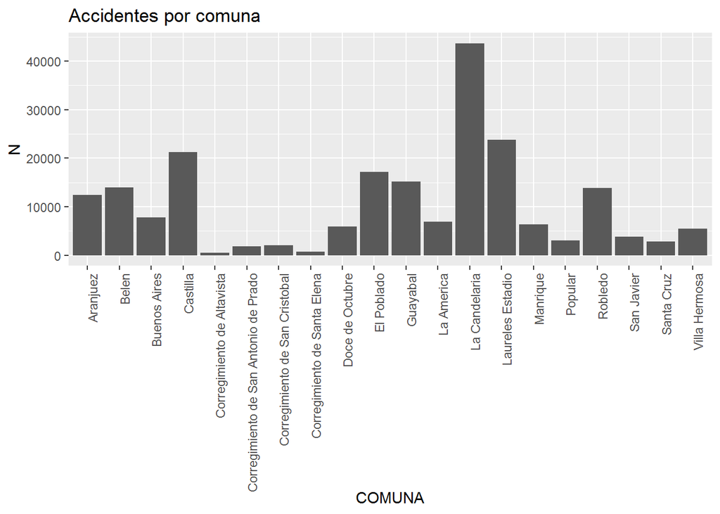

```r
comunas_relev<- unlist(split(comunas_relevantes, seq(nrow(comunas_relevantes))), use.names = FALSE) ##get the names we want


com <- aggregate(RADICADO ~ COMUNA, data = df2[df2$COMUNA %in% comunas_relev , ], FUN = length) ##genera tabla para graficar (cuenta radicados agrupados por gravedad y comuna)


ggplot(data=com, aes(x=COMUNA, y=RADICADO)) +
    geom_bar(stat="identity")+
    theme(axis.text.x = element_text(angle = 90, hjust = 1)) +
  labs(title="Accidentes por comuna", y = "N")
```

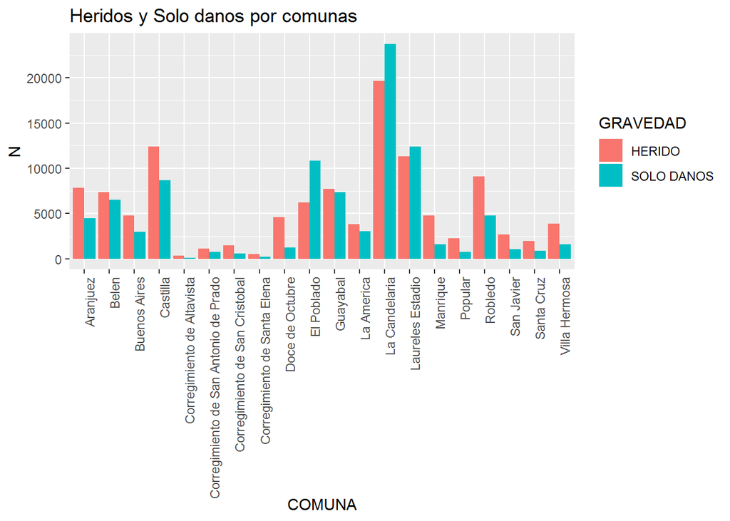

```r
##Conteo a traves de Radicado o ID son practicament equivalentes


com_grav <- aggregate(RADICADO ~ GRAVEDAD + COMUNA, data = df2[df2$COMUNA %in% comunas_relev , ], FUN = length) ##genera tabla para graficar (cuenta radicados agrupados por gravedad y comuna)


ggplot(data=com_grav[com_grav$GRAVEDAD != "MUERTO",], aes(x=COMUNA, y=RADICADO, fill=GRAVEDAD)) +
    geom_bar(stat="identity", position=position_dodge())+
    theme(axis.text.x = element_text(angle = 90, hjust = 1))+
  labs(title="Heridos y Solo danos por comunas", y = "N")
```

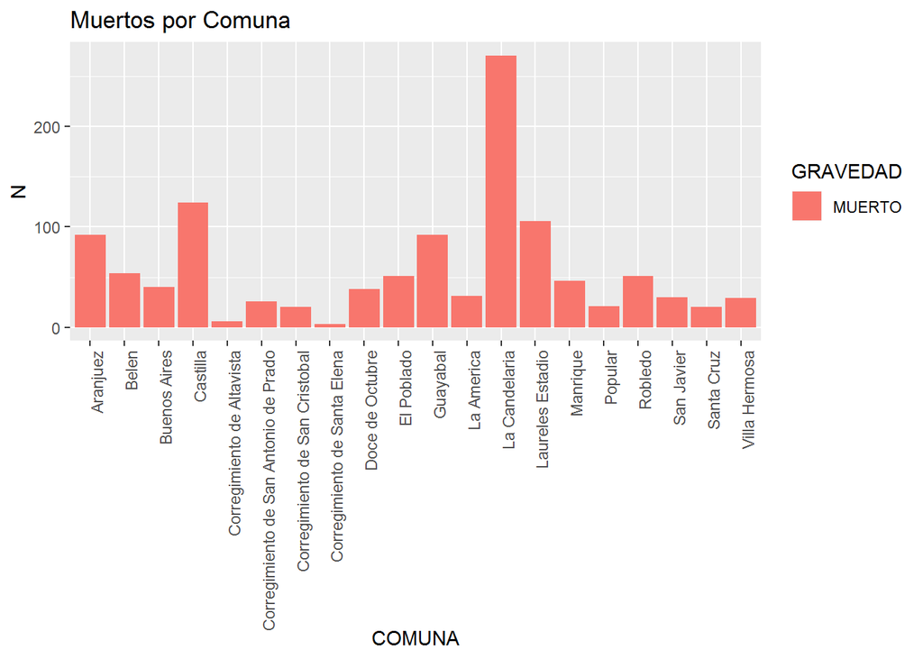

```r
ggplot(data=com_grav[com_grav$GRAVEDAD == "MUERTO",], aes(x=COMUNA, y=RADICADO, fill=GRAVEDAD)) +
    geom_bar(stat="identity")+
    theme(axis.text.x = element_text(angle = 90, hjust = 1)) +
  labs(title="Muertos por Comuna", y = "N")
```

###Grafico de frecuencias relativas para Gravedad

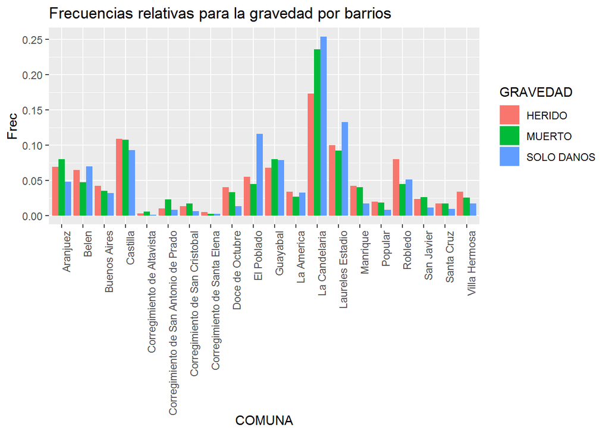

```r
frec_grav <- com_grav
frec_grav[frec_grav$GRAVEDAD == "HERIDO", ]$RADICADO <- frec_grav[frec_grav$GRAVEDAD == "HERIDO", ]$RADICADO/sum(frec_grav[frec_grav$GRAVEDAD == "HERIDO", ]$RADICADO)

frec_grav[frec_grav$GRAVEDAD == "MUERTO", ]$RADICADO <- frec_grav[frec_grav$GRAVEDAD == "MUERTO", ]$RADICADO/sum(frec_grav[frec_grav$GRAVEDAD == "MUERTO", ]$RADICADO)

frec_grav[frec_grav$GRAVEDAD == "SOLO DANOS", ]$RADICADO <- frec_grav[frec_grav$GRAVEDAD == "SOLO DANOS", ]$RADICADO/sum(frec_grav[frec_grav$GRAVEDAD == "SOLO DANOS", ]$RADICADO)

ggplot(data=frec_grav, aes(x=COMUNA, y=RADICADO, fill=GRAVEDAD)) +
    geom_bar(stat="identity", position=position_dodge())+
    theme(axis.text.x = element_text(angle = 90, hjust = 1))+
  labs(title="Frecuencias relativas para la gravedad por barrios", y = "Frec")
```

Este grafico nos indica que para algunas comunas las proporciones de Heridos, muertos y solo daños son diferentes,lo que indica características distintas que pueden aumentar los riesgos de sufrir lesiones dependiendo de la comuna.

###Tipo accidente y comunas/barrios

Para los tipos de accidentes se eligen los 5 tipos de mayor frecuencia en los accidentes. Choque 141305  
Otro 22017  
Atropello 20667  
Caida Ocupante 18532  
Volcamiento 6613

Se descartan los demás cuya frecuencia era inferior a 25.

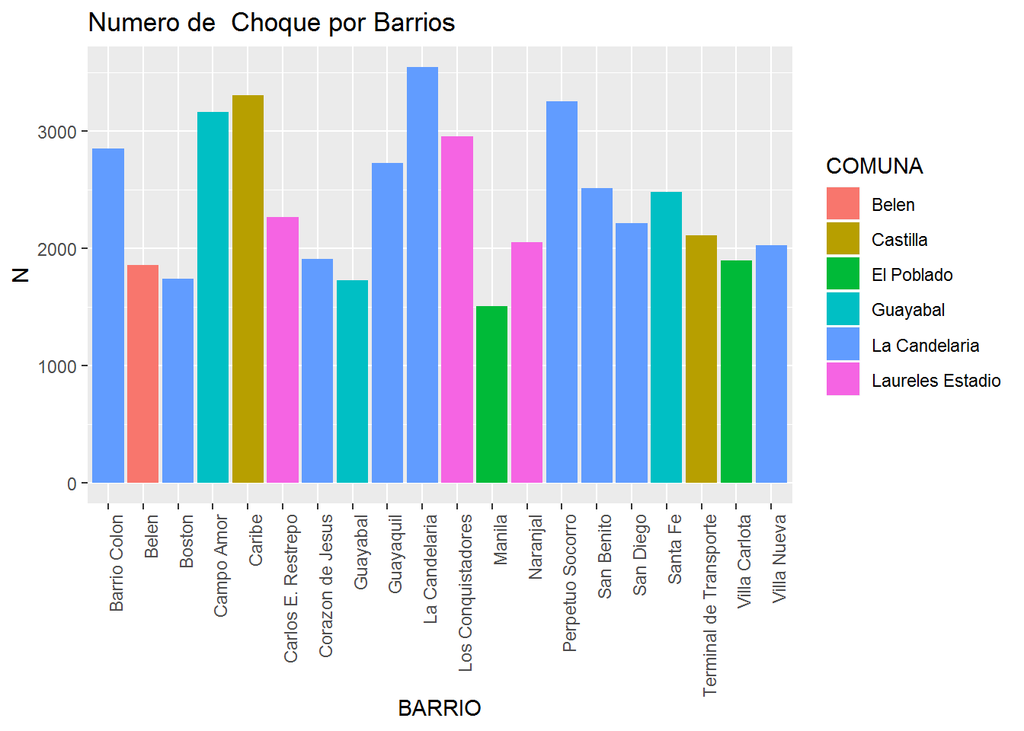

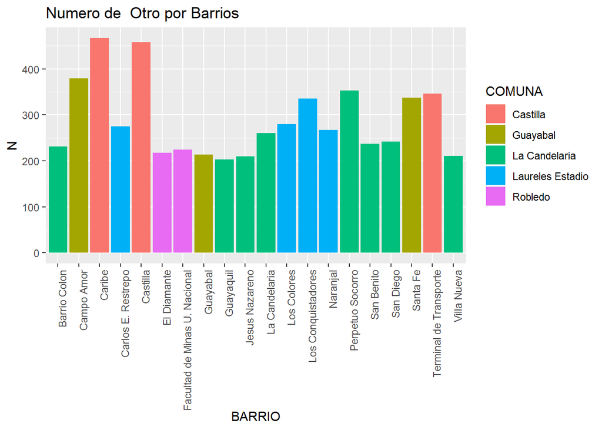

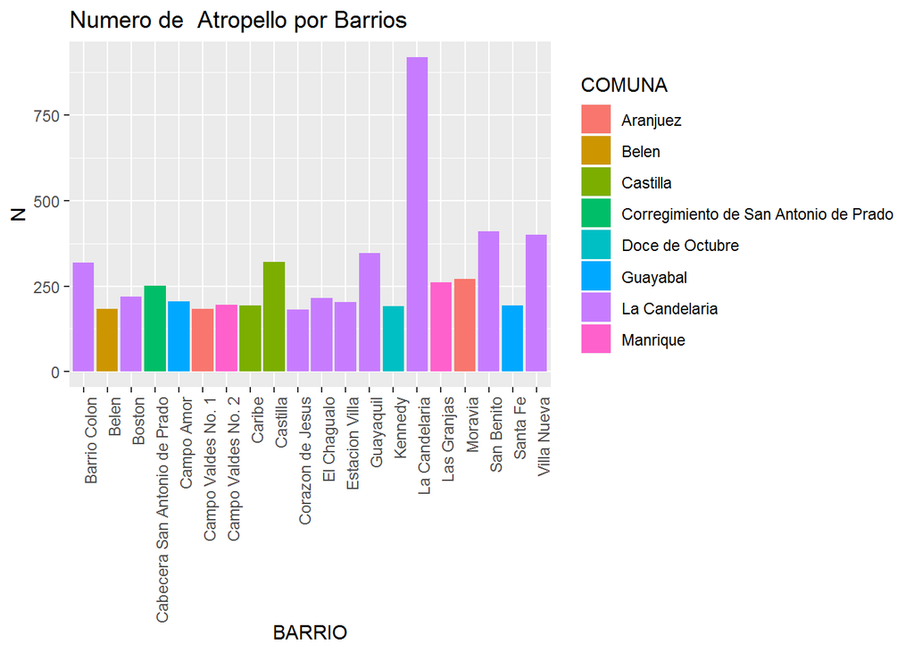

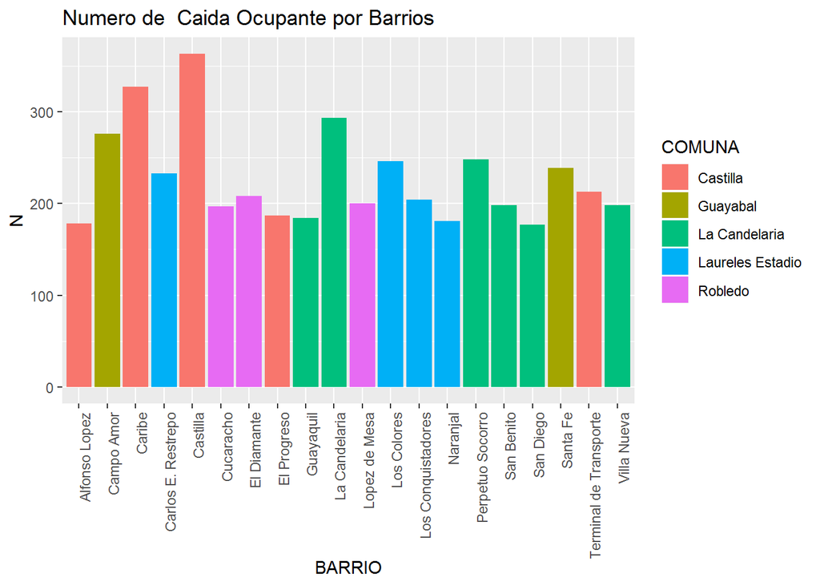

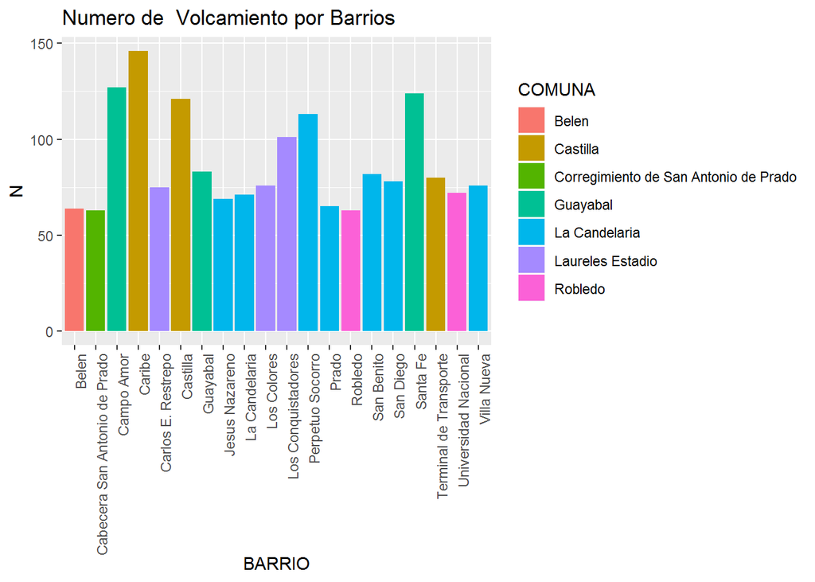

```r
clase_c<-count(df2, CLASE)
clase_relev <- head(clase_c[order(-clase_c$n),], 5)[1]
clase_relev<- unlist(split(clase_relev, seq(nrow(clase_relev))), use.names = FALSE) ##get the type of accidents that kinda matter

com_acc <- aggregate(RADICADO ~ CLASE + BARRIO + COMUNA, data = df2[df2$CLASE %in% clase_relev , ], FUN = length)


graphxClass <- function(clase, cl_df = com_acc){
  cl_df <- cl_df[cl_df$CLASE== clase,]
  cl_df2 <- head(cl_df[order(-cl_df$RADICADO),], 20)
  ggplot(data=cl_df2, aes(x=BARRIO, y=RADICADO, fill=COMUNA)) +
    geom_bar(stat="identity", position=position_dodge())+
    theme(axis.text.x = element_text(angle = 90, hjust = 1))+
  labs(title=paste("Numero de ",clase, "por Barrios"), y = "N")

}

lapply(clase_relev, graphxClass)
```

### Graficos para barrios

De momento lo omito, se espera que pase lo mismo que con el de comunas.

```r
barrios <- count(df2, BARRIO) #EN su mayoria las comunas con menos de 4 accidentes son tabulaciones erroneas d eun barrio
#barrios[order(-barrios$n),] AQUI PARA VER LOS BARRIOS
barrios_relevantes <- head(barrios[order(-barrios$n),][1], 20)
#Para las comunas relevantes se tienen las 16 de medellin, y las 24 primeras corregimientos y otros lugares menos relevantes.
#Se eligen las 16 comunas de medellín y los 4 corregimientos de mayor tamaño.
```

```r
Barr_grav <- aggregate(RADICADO ~ BARRIO + COMUNA + GRAVEDAD, data = df2, FUN = length) ##genera tabla para graficar (cuenta radicados agrupados por gravedad y comuna)
```

##Graficos unidades de tiempo

##Frecuencia por dias

[figure not shown]

```r
dias <- aggregate(RADICADO ~ DIA, data = df2, FUN = length)
dias_sem <- aggregate(RADICADO ~ DIA_NOMBRE, data = df2, FUN = length)

meses <- aggregate(RADICADO ~ MES, data = df2, FUN = length)

ggplot(data=dias, aes(x=DIA, y=RADICADO)) +
    geom_bar(stat="identity")+
    theme(axis.text.x = element_text(angle = 90, hjust = 1))+
  labs(title="Heridos y Solo danos por comunas", y = "N")
```

[figure not shown]

```r
ggplot(data=dias_sem, aes(x=DIA_NOMBRE, y=RADICADO)) +
    geom_bar(stat="identity")+
    theme(axis.text.x = element_text(angle = 90, hjust = 1))+
  labs(title="Heridos y Solo danos por comunas", y = "N")
```

[figure not shown]

```r
ggplot(data=meses, aes(x=MES, y=RADICADO)) +
    geom_bar(stat="identity")+
    theme(axis.text.x = element_text(angle = 90, hjust = 1))+
  labs(title="Heridos y Solo danos por comunas", y = "N")
```